# EXAMEN 2016

Software Estadístico II

26 de noviembre de 2017

### EJERCICIO 1

#### Dado un número entero positivo n, sume los cuadrados de los enteros entre 1 y nn. Verifique si esta suma es múltiplo de n.

```r
n<-12
sc<-ifelse(sum((1:n)^2)%%n==0,paste(sum((1:n)^2),' es múltiplo de ',n),paste(sum((1:n)^2),' no es múltiplo de',n))
sc
```

```
## [1] "650  no es múltiplo de 12"
```

### EJERCICIO 2

#### Simule el lanzamiento de un dado 1000000 veces. Muestre la cantidad de veces que sale cada número.

- Resuélvelo utilizando $for$.

```r
simulacion1<-NULL
t.inicio1<-proc.time()
for(i in 1:1000000)
  simulacion1<-append(simulacion1,sample(1:6,1))
table(simulacion1)
t.final1<-proc.time()
```

- Resuélvelo vectorizando.

```r
# b. VECTORIZANDO
t.inicio2<-proc.time()
simulacion2<-sample(1:6,1000000,replace=TRUE)
table(simulacion2)
```

```
## simulacion2
##      1      2      3      4      5      6
## 166419 166900 166566 166795 167303 166017
```

```r
t.final2<-proc.time()
```

Ahora comparamos los tiempos de ejecución (SI SE EJECUTAR TARDA MUCHO CON EL for):

```r
tiempo1<-t.final1-t.inicio1
tiempo2<-t.final2-t.inicio2

tiempo1
tiempo2

#otra forma:

system.time({
  simulacion1<-NULL
  for(i in 1:1000000)
    simulacion1<-append(simulacion1,sample(1:6,1))
  table(simulacion1)
})

system.time({
  simulacion2<-sample(1:6,1000000,replace=TRUE)
  table(simulacion2)
})
```

### EJERCICIO 3

#### Dado el siguiente vector:

```r
x<-c(8,23,15,NA,21,7,NA,NA,6,91,NA,12)
```

- Escribe un programa que devuelva las posiciones de lso valores peridos de x.

```r
which(is.na(x))
```

```
## [1]  4  7  8 11
```

- Escribe un programa que de el número de valores no perdidos en x.

```r
sum(!is.na(x))
```

```
## [1] 8
```

- Escribe un programa que cambie los valores peridos de x por la mediana de los valores no perdidos.

```r
ifelse(is.na(x),median(x,na.rm=T),x)
```

```
##  [1]  8.0 23.0 15.0 13.5 21.0  7.0 13.5 13.5  6.0 91.0 13.5 12.0
```

- Escribe una función con argumento de entrada un vector x y que devuelva un vector con los valores reemplazados por la media de los valores no perdidos de x.

```r
reemplazo<-function(x) ifelse(is.na(x),mean(x,na.rm=TRUE),x)
reemplazo(x)
```

```
##  [1]  8.000 23.000 15.000 22.875 21.000  7.000 22.875 22.875  6.000 91.000
## [11] 22.875 12.000
```

### EJERCICIO 4

#### Dado el data.frame mtcars de la librería datasets:

- Escribe un programa que dibuje un gráfico de dispersión de la variable hp frente a mpg, utilizando un color diferente para cada nivel de la variable carb.

```r
data(mtcars)
str(mtcars)
```

```
## 'data.frame':    32 obs. of  11 variables:
##  $ mpg : num  21 21 22.8 21.4 18.7 18.1 14.3 24.4 22.8 19.2 ...
##  $ cyl : num  6 6 4 6 8 6 8 4 4 6 ...
##  $ disp: num  160 160 108 258 360 ...
##  $ hp  : num  110 110 93 110 175 105 245 62 95 123 ...
##  $ drat: num  3.9 3.9 3.85 3.08 3.15 2.76 3.21 3.69 3.92 3.92 ...
##  $ wt  : num  2.62 2.88 2.32 3.21 3.44 ...
##  $ qsec: num  16.5 17 18.6 19.4 17 ...
##  $ vs  : num  0 0 1 1 0 1 0 1 1 1 ...
##  $ am  : num  1 1 1 0 0 0 0 0 0 0 ...
##  $ gear: num  4 4 4 3 3 3 3 4 4 4 ...
##  $ carb: num  4 4 1 1 2 1 4 2 2 4 ...
```

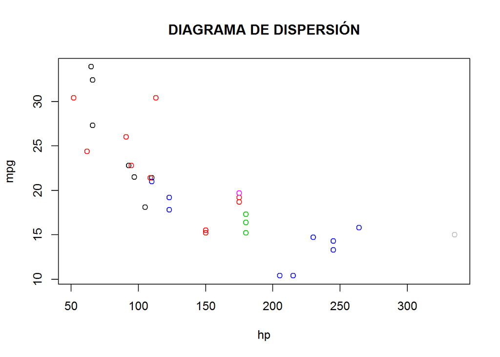

```r
plot(mtcars$mpg~mtcars$hp,
     col=mtcars$carb,
     main='DIAGRAMA DE DISPERSIÓN',
     xlab='hp',ylab='mpg')
```

- Escribe un programa que ordene las filas del data frame en función de la columna hp

```r
orden<-order(mtcars$hp)
mtcars[orden,]
```

```
##                      mpg cyl  disp  hp drat    wt  qsec vs am gear carb
## Honda Civic         30.4   4  75.7  52 4.93 1.615 18.52  1  1    4    2
## Merc 240D           24.4   4 146.7  62 3.69 3.190 20.00  1  0    4    2
## Toyota Corolla      33.9   4  71.1  65 4.22 1.835 19.90  1  1    4    1
## Fiat 128            32.4   4  78.7  66 4.08 2.200 19.47  1  1    4    1
## Fiat X1-9           27.3   4  79.0  66 4.08 1.935 18.90  1  1    4    1
## Porsche 914-2       26.0   4 120.3  91 4.43 2.140 16.70  0  1    5    2
## Datsun 710          22.8   4 108.0  93 3.85 2.320 18.61  1  1    4    1
## Merc 230            22.8   4 140.8  95 3.92 3.150 22.90  1  0    4    2
## Toyota Corona       21.5   4 120.1  97 3.70 2.465 20.01  1  0    3    1
## Valiant             18.1   6 225.0 105 2.76 3.460 20.22  1  0    3    1
## Volvo 142E          21.4   4 121.0 109 4.11 2.780 18.60  1  1    4    2
## Mazda RX4           21.0   6 160.0 110 3.90 2.620 16.46  0  1    4    4
## Mazda RX4 Wag       21.0   6 160.0 110 3.90 2.875 17.02  0  1    4    4
## Hornet 4 Drive      21.4   6 258.0 110 3.08 3.215 19.44  1  0    3    1
## Lotus Europa        30.4   4  95.1 113 3.77 1.513 16.90  1  1    5    2
## Merc 280            19.2   6 167.6 123 3.92 3.440 18.30  1  0    4    4
## Merc 280C           17.8   6 167.6 123 3.92 3.440 18.90  1  0    4    4
## Dodge Challenger    15.5   8 318.0 150 2.76 3.520 16.87  0  0    3    2
## AMC Javelin         15.2   8 304.0 150 3.15 3.435 17.30  0  0    3    2
## Hornet Sportabout   18.7   8 360.0 175 3.15 3.440 17.02  0  0    3    2
## Pontiac Firebird    19.2   8 400.0 175 3.08 3.845 17.05  0  0    3    2
## Ferrari Dino        19.7   6 145.0 175 3.62 2.770 15.50  0  1    5    6
## Merc 450SE          16.4   8 275.8 180 3.07 4.070 17.40  0  0    3    3
## Merc 450SL          17.3   8 275.8 180 3.07 3.730 17.60  0  0    3    3
## Merc 450SLC         15.2   8 275.8 180 3.07 3.780 18.00  0  0    3    3
## Cadillac Fleetwood  10.4   8 472.0 205 2.93 5.250 17.98  0  0    3    4
## Lincoln Continental 10.4   8 460.0 215 3.00 5.424 17.82  0  0    3    4
## Chrysler Imperial   14.7   8 440.0 230 3.23 5.345 17.42  0  0    3    4
## Duster 360          14.3   8 360.0 245 3.21 3.570 15.84  0  0    3    4
## Camaro Z28          13.3   8 350.0 245 3.73 3.840 15.41  0  0    3    4
## Ford Pantera L      15.8   8 351.0 264 4.22 3.170 14.50  0  1    5    4
## Maserati Bora       15.0   8 301.0 335 3.54 3.570 14.60  0  1    5    8
```

```r
# CON dplyr
library(dplyr)
mtcars %>% arrange(hp)
```

```
##     mpg cyl  disp  hp drat    wt  qsec vs am gear carb
## 1  30.4   4  75.7  52 4.93 1.615 18.52  1  1    4    2
## 2  24.4   4 146.7  62 3.69 3.190 20.00  1  0    4    2
## 3  33.9   4  71.1  65 4.22 1.835 19.90  1  1    4    1
## 4  32.4   4  78.7  66 4.08 2.200 19.47  1  1    4    1
## 5  27.3   4  79.0  66 4.08 1.935 18.90  1  1    4    1
## 6  26.0   4 120.3  91 4.43 2.140 16.70  0  1    5    2
## 7  22.8   4 108.0  93 3.85 2.320 18.61  1  1    4    1
## 8  22.8   4 140.8  95 3.92 3.150 22.90  1  0    4    2
## 9  21.5   4 120.1  97 3.70 2.465 20.01  1  0    3    1
## 10 18.1   6 225.0 105 2.76 3.460 20.22  1  0    3    1
## 11 21.4   4 121.0 109 4.11 2.780 18.60  1  1    4    2
## 12 21.0   6 160.0 110 3.90 2.620 16.46  0  1    4    4
## 13 21.0   6 160.0 110 3.90 2.875 17.02  0  1    4    4
## 14 21.4   6 258.0 110 3.08 3.215 19.44  1  0    3    1
```

[output cut: 18 more lines]

- Escribe un programa que muestre el número de la observación donde se alcanza el máximo de la razón entre mpg y wt.

```r
razon<-mtcars$mpg/mtcars$wt
which.max(razon)
```

```
## [1] 28
```

### EJERCICIO 5

#### Dado el fichero de datos “wine.data.txt” que contiene información sobre la composición química de diferentes tipos de vinos y su fichero descriptor “wine.names.txt”.

- Escribe un programa que cree el data.frame wine con los nombres de las variables….

```r
# guardamos los nombres
nombres<-c('Type','Alcohol','Malic.Acid','Ash','Alcalinity.of.ash',
           'Magnesium','Total.phenols','Flavanoids','Nonflavanoid.phenols',
           'Proanthocyaninis','Color.intensity','Hue','Diluted.wines','Proline')

# leemos el fichero externo y lo guardamos en el data.frame wine
setwd('C:/Rproy/soft_estad_ii_upm')
wine<-read.table(paste(getwd(),'/wine.txt',sep=''),sep=',')
str(wine)
```

```
## 'data.frame':    178 obs. of  14 variables:
##  $ V1 : int  1 1 1 1 1 1 1 1 1 1 ...
##  $ V2 : num  14.2 13.2 13.2 14.4 13.2 ...
##  $ V3 : num  1.71 1.78 2.36 1.95 2.59 1.76 1.87 2.15 1.64 1.35 ...
##  $ V4 : num  2.43 2.14 2.67 2.5 2.87 2.45 2.45 2.61 2.17 2.27 ...
##  $ V5 : num  15.6 11.2 18.6 16.8 21 15.2 14.6 17.6 14 16 ...
##  $ V6 : int  127 100 101 113 118 112 96 121 97 98 ...
##  $ V7 : num  2.8 2.65 2.8 3.85 2.8 3.27 2.5 2.6 2.8 2.98 ...
##  $ V8 : num  3.06 2.76 3.24 3.49 2.69 3.39 2.52 2.51 2.98 3.15 ...
##  $ V9 : num  0.28 0.26 0.3 0.24 0.39 0.34 0.3 0.31 0.29 0.22 ...
##  $ V10: num  2.29 1.28 2.81 2.18 1.82 1.97 1.98 1.25 1.98 1.85 ...
##  $ V11: num  5.64 4.38 5.68 7.8 4.32 6.75 5.25 5.05 5.2 7.22 ...
##  $ V12: num  1.04 1.05 1.03 0.86 1.04 1.05 1.02 1.06 1.08 1.01 ...
##  $ V13: num  3.92 3.4 3.17 3.45 2.93 2.85 3.58 3.58 2.85 3.55 ...
##  $ V14: int  1065 1050 1185 1480 735 1450 1290 1295 1045 1045 ...
```

```r
# asignamos los nombres deseados, y comprobamos la estructura
colnames(wine)<-nombres
str(wine)
```

```
## 'data.frame':    178 obs. of  14 variables:
##  $ Type                : int  1 1 1 1 1 1 1 1 1 1 ...
##  $ Alcohol             : num  14.2 13.2 13.2 14.4 13.2 ...
##  $ Malic.Acid          : num  1.71 1.78 2.36 1.95 2.59 1.76 1.87 2.15 1.64 1.35 ...
##  $ Ash                 : num  2.43 2.14 2.67 2.5 2.87 2.45 2.45 2.61 2.17 2.27 ...
##  $ Alcalinity.of.ash   : num  15.6 11.2 18.6 16.8 21 15.2 14.6 17.6 14 16 ...
##  $ Magnesium           : int  127 100 101 113 118 112 96 121 97 98 ...
##  $ Total.phenols       : num  2.8 2.65 2.8 3.85 2.8 3.27 2.5 2.6 2.8 2.98 ...
##  $ Flavanoids          : num  3.06 2.76 3.24 3.49 2.69 3.39 2.52 2.51 2.98 3.15 ...
##  $ Nonflavanoid.phenols: num  0.28 0.26 0.3 0.24 0.39 0.34 0.3 0.31 0.29 0.22 ...
##  $ Proanthocyaninis    : num  2.29 1.28 2.81 2.18 1.82 1.97 1.98 1.25 1.98 1.85 ...
##  $ Color.intensity     : num  5.64 4.38 5.68 7.8 4.32 6.75 5.25 5.05 5.2 7.22 ...
##  $ Hue                 : num  1.04 1.05 1.03 0.86 1.04 1.05 1.02 1.06 1.08 1.01 ...
##  $ Diluted.wines       : num  3.92 3.4 3.17 3.45 2.93 2.85 3.58 3.58 2.85 3.55 ...
##  $ Proline             : int  1065 1050 1185 1480 735 1450 1290 1295 1045 1045 ...
```

- Escribe un programa que calcule la mediana de Alcohol y Malic.Acid para cada tipo de vino (Type).

```r
tapply(wine$Alcohol,wine$Type,median)
```

```
##      1      2      3
## 13.750 12.290 13.165
```

```r
tapply(wine$Malic.Acid,wine$Type,median)
```

```
##     1     2     3
## 1.770 1.610 3.265
```

- Escribe un programa que realice un gráfico de barras mostrando el número de vinos de cada tipo que hay en el data.frame.

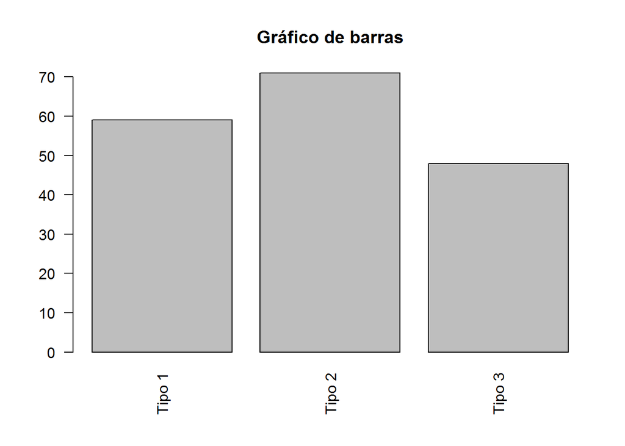

```r
wine$Type<-factor(wine$Type,levels=1:3,labels=c('Tipo 1','Tipo 2','Tipo 3'))
barplot(table(wine$Type),
        main='Gráfico de barras',
        las=2)
```

```r
#el parámetro 'las = 0,1,2,3' rota los valores de los ejes
```

- Escribe un programa que cuente el númer ode observaciones con Alcohol mayor que 13 y Proline menor que 650.

```r
sum(wine$Alcohol>13 & wine$Proline<650)
```

```
## [1] 20
```

```r
#con dplyr
wine %>% filter(Alcohol>13,Proline<650) %>% summarise(n())
```

```
##   n()
## 1  20
```

### EJERCICIO 6

#### Dada la función

$$f(x)=\left\{\begin{array}{l}
\frac{\ln(1-x)}{1-x} & x<0\\
\\
x\mathrm{e}^{-x} & x\geq 0
\end{array}\right.$$

- Dibuja $f(x)$ utilizando el valor 1 en la opción type.